# Chap10.1-10.2

Mijeong Kim

```r
library(tsibble)
library(tsibbledata)
library(tibble)
library(dplyr)
library(knitr)
library(ggplot2)
library(fpp3)
library(fpp2)
library(seasonal)
library(feasts)
```

# Chapter 10 Dynamic regression models

#### 1. 기존 모델의 한계

- **ARIMA 모델**: 과거 시계열 정보는 반영하지만, **외부 변수(holiday, 정책, 경제 변수 등)**는 반영하지 못함
- **회귀 모델 (Chapter 7)**: 외생 변수는 반영 가능하지만, **시계열 특유의 자기상관 구조**는 고려하지 않음

#### 2. 동적 회귀모형의 개념

**회귀 + ARIMA 오차 구조**를 결합한 모델:

$$y_t = \beta_0 + \beta_1 x_{1,t} + \cdots + \beta_k x_{k,t} + \eta_t$$

- $x_{i,t}$: 설명 변수들
- $\eta_t$: **ARIMA 모델을 따르는 오차항**
- 오직 ARIMA 오차 $\varepsilon_t$만이 백색잡음(white noise)으로 가정됨

#### 3. 예시: ARIMA(1,1,1) 오차 구조를 가진 회귀모형

$$(1 - \phi_1 B)(1 - B)\eta_t = (1 + \theta_1 B)\varepsilon_t$$

- 회귀 오차 $\eta_t$는 **ARIMA(1,1,1)** 모형을 따른다.
- 전체 모델은 **설명 변수**와 **자기상관 구조를 가진 잔차**를 모두 반영

#### 4. 핵심 요약

- 동적 회귀모형은 **예측 정확도 향상**에 매우 효과적임
- **ARIMA의 시계열 특성과 회귀의 외생 변수 활용**을 통합
- 잔차에 **자기상관이 존재**할 경우, 이 모형이 적절한 대안이 될 수 있음

## 10.1 Estimation

#### 1. 오차 항 추정의 핵심

- 동적 회귀모형에서 모수 추정 시 **ARIMA 오차의 백색잡음($\epsilon_t$)**에 대해 **제곱합 최소화**가 필요함.
- 만약 **the sum of squared $\eta_t$ 을 최소화**하면 아래와 같은 문제 발생:
  - $\beta_0, \cdots, \beta_k$ 추정치가 최적이 아님 (자기상관 정보 무시)
  - t-검정 등 **통계적 검정이 잘못된 결과**를 줄 수 있음
  - AICc 값이 **예측 성능을 잘 반영하지 못함**
  - 유의하지 않은 변수들이 **유의한 것처럼 보이는 “허위 회귀(spurious regression)”** 발생

→ **$\epsilon_t$ 제곱합 최소화 또는 최대우도법(Maximum Likelihood Estimation)** 사용 권장

#### 2. 정상성 조건 (Stationarity)

- ARIMA 오차를 포함한 회귀모델을 추정할 때는 **모든 변수(종속 + 설명변수)가 정상성**을 가져야 함.
- 비정상 변수로 추정할 경우, **모수 일관성(consistency)**이 보장되지 않음

#### 예외: 공적분(cointegration)

- 비정상 변수라도 선형 결합이 정상일 경우 → 추정 계수는 유의미함

#### 3. 차분(differencing) 모델로의 변환

- 변수 중 하나라도 비정상이면, **모든 변수에 차분 적용**하는 것이 일반적임
- 이때 얻어지는 모형은 **“차분 모형(model in differences)”**이라 부르며, 원 자료 그대로 사용하는 **“수준 모형(model in levels)”**과 구분됨

#### 예시: ARIMA(1,1,1) 오차를 갖는 회귀모형 → 차분 후 모델

$$y'_t = \beta_1 x'_{1,t} + \cdots + \beta_k x'_{k,t} +
\eta'_t$$

$$(1 - \phi_1 B) \eta'_t = (1 + \theta_1 B) \varepsilon_t$$

- 여기서:
  - $y'_t = y_t - y_{t-1}$
  - $x'_{i,t} = x_{i,t} - x_{i,t-1}$
  - $\eta'_t = \eta_t - \eta_{t-1}$

→ 이는 **ARMA 오차를 갖는 차분 회귀모형**으로 해석됨

#### 요약

- **모형 오차의 자기상관**을 고려하지 않으면 잘못된 해석 가능
- **모든 변수의 정상성 확인**은 필수
- 필요시 **차분하여 일관성 있는 회귀 추정** 수행
- **ARIMA 오차 회귀모형 ≒ 차분된 ARMA 오차 회귀모형**

## 10.2 Regression with ARIMA errors using fable

ARIMA() 함수는 **외생 변수(exogenous regressors)**가 포함된 경우, ARIMA 오차를 갖는 회귀모형을 적합시킨다.

- pdq() 함수를 사용하여 **오차항의 ARIMA 차수(p, d, q)**를 지정할 수 있다. (9.5절 참고)

차분(d)이 지정되면, 회귀모형의 모든 변수에 차분이 적용된 후 모델이 추정된다. 예를 들어, 아래 명령어

ARIMA(y ~ x + pdq(1,1,0))

위 모델은 다음과 같은 형태임:

$$y_t' = \beta_1 x_t' + \eta_t', \quad \text{where} \quad
\eta_t' = \phi_1 \eta_{t-1}' + \varepsilon_t \sim \text{AR}(1)$$

이는 다음과 같은 모델과 동치:

$$y_t = \beta_0+ \beta_1 x_t + \eta_t, \quad \eta_t \sim
\text{ARIMA}(1,1,0)$$

**차분된 모형에서는 차분(d = 1)**이 적용되어 상수항 $\beta_0$ 은 사라짐

상수항 포함 시: ARIMA(y ~ x + 1 + pdq(1,1,0))

### Example: US Personal Consumption and Income

그림 10.1은 1970년부터 2019년 2분기까지의 개인 소비 지출 및 가처분 소득의 분기별 변화를 보여준다. 본 예제에서는 소득 변화가 소비 지출 변화에 미치는 즉각적인 평균 효과를 추정하고자 하며, 실제 존재할 수 있는 시간 지연 효과는 고려하지 않고 단순화하여 분석을 진행한다.

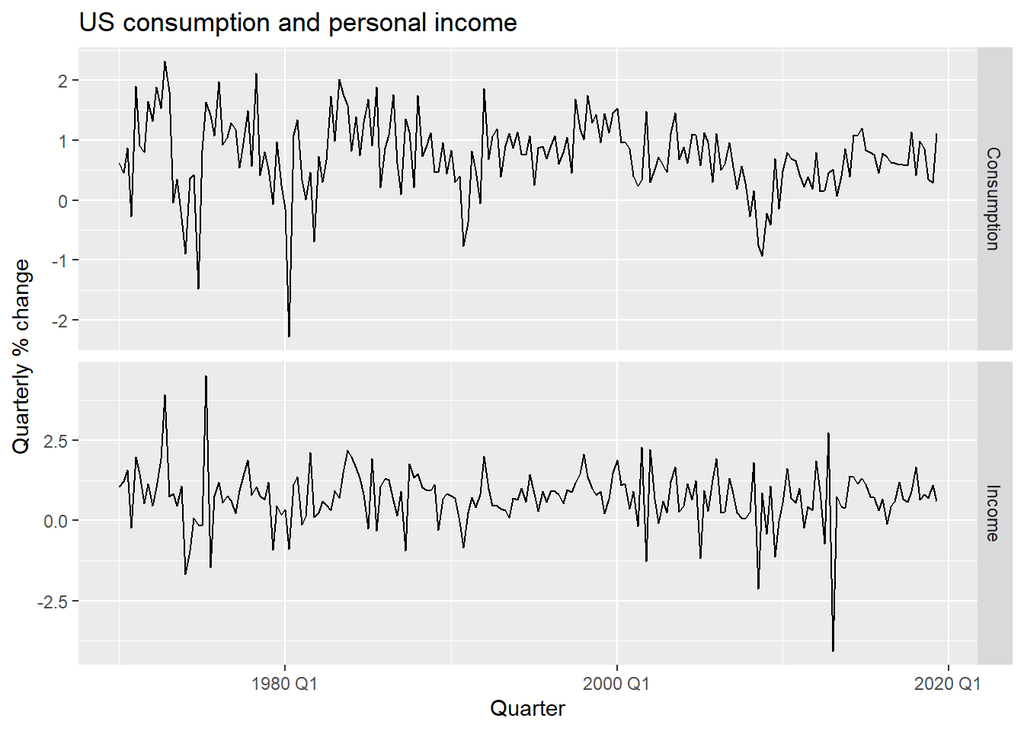

```r
us_change |>
  pivot_longer(c(Consumption, Income),
               names_to = "var", values_to = "value") |>
  ggplot(aes(x = Quarter, y = value)) +
  geom_line() +
  facet_grid(vars(var), scales = "free_y") +
  labs(title = "US consumption and personal income",
       y = "Quarterly % change")
```

Figure 10.1: Percentage changes in quarterly personal consumption expenditure and personal disposable income for the USA, 1970 Q1 to 2019 Q2.

```r
fit <- us_change |>
  model(ARIMA(Consumption ~ Income))
report(fit)
```

```
## Series: Consumption
## Model: LM w/ ARIMA(1,0,2) errors
##
## Coefficients:
##          ar1      ma1     ma2  Income  intercept
##       0.7070  -0.6172  0.2066  0.1976     0.5949
## s.e.  0.1068   0.1218  0.0741  0.0462     0.0850
##
## sigma^2 estimated as 0.3113:  log likelihood=-163.04
## AIC=338.07   AICc=338.51   BIC=357.8
```

- **소득과 지출의 변화율(%)**을 사용하므로, 데이터는 이미 **정상성(stationarity)**을 만족하며 차분이 필요하지 않음
- 적합된 회귀 + ARIMA 모델은 다음과 같음:

$$\begin{aligned}
y_t &= 0.595 + 0.198 x_t + \eta_t,\\
\eta_t &=0.707 \eta_{t-1} + \varepsilon_t - 0.617 \varepsilon_{t-1}
+ 0.207 \varepsilon_{t-2},\\
\varepsilon_t &\sim \text{NID}(0, 0.311).
\end{aligned}$$

- residuals() 함수를 통해 $\eta_t$ 및 $\epsilon_t$ 시계열의 추정값을 복원할 수 있음

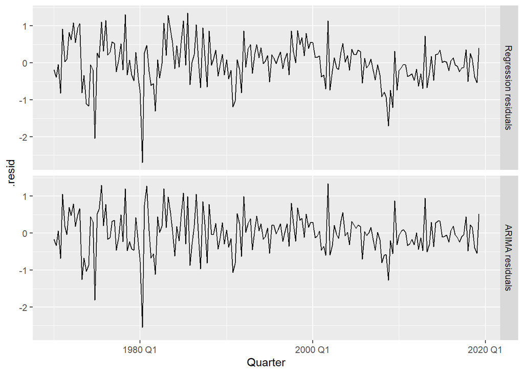

```r
bind_rows(
    `Regression residuals` =
        as_tibble(residuals(fit, type = "regression")),
    `ARIMA residuals` =
        as_tibble(residuals(fit, type = "innovation")),
    .id = "type"
  ) |>
  mutate(
    type = factor(type, levels=c(
      "Regression residuals", "ARIMA residuals"))
  ) |>
  ggplot(aes(x = Quarter, y = .resid)) +
  geom_line() +
  facet_grid(vars(type))
```

Figure 10.2: Regression residuals $\eta_t$ and ARIMA residuals $\epsilon_t$ from the fitted model.

**백색잡음 시계열과 유사해야 하는 것은 ARIMA에서 추정된 오차(혁신 잔차)**이다.

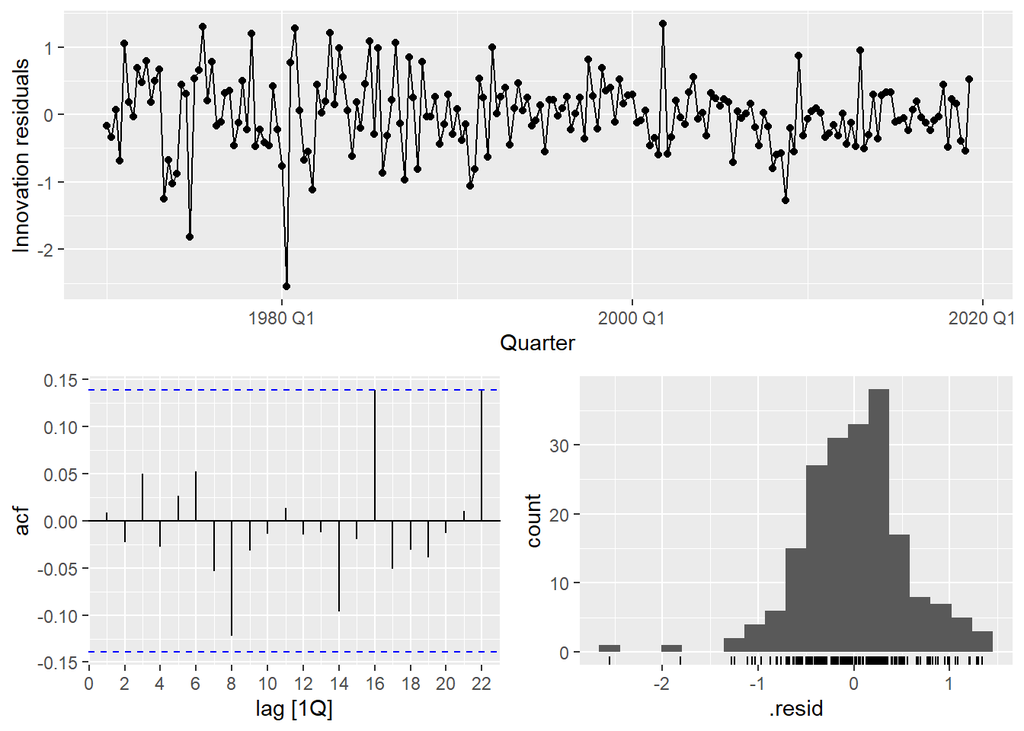

```r
fit |> gg_tsresiduals()
```

Figure 10.3: The innovation residuals (i.e., the estimated ARIMA errors) are not significantly different from white noise.

```r
augment(fit) |>
  features(.innov, ljung_box, dof = 3, lag = 8)
```

```
## # A tibble: 1 × 3
##   .model                      lb_stat lb_pvalue
##   <chr>                         <dbl>     <dbl>
## 1 ARIMA(Consumption ~ Income)    5.21     0.391
```